# Comparison of Methods on a Tuberculosis Outbreak in London

Gerry Tonkin-Hill

2019-09-16

## Load libraries

```r
library(ggplot2)
library(data.table)
library(purrr)
library(RColorBrewer)
```

To investigate the ability of different methods to accurately infer the pangenome from real data we investigated a large Tuberculosis outbreak in London:

> Casali,N., Broda,A., Harris,S.R., Parkhill,J., Brown,T. and Drobniewski,F. (2016) Whole Genome Sequence Analysis of a Large Isoniazid-Resistant Tuberculosis Outbreak in London: A Retrospective Observational Study. PLoS Med., 13, e1002137.

This provided a suitable control as *M. tuberculosis* is not thought to have a pangenome. The low mutation rate of *M. tuberculosis* (0.5 snps/year) also led to only one of these isolates having diverged by more than 5 SNPs. Thus we would not expect variation in the accessory genome and would expect nearly all genes to be ‘core’ genes.

## Running different pangenome tools

**Roary**

```
roary -f roary_out -p 20 ./*.gff
```

**PIRATE**

```
mkdir pirate_out
~/panaroo/scripts/run_pirate.py -i ./*.gff -o pirate_out/ -t 20
```

This is the equivalent to running PIRATE as

```
cp ./*.gff ./pirate_out/
PIRATE -i pirate_out -o pirate_out -t 20
```

**PanX**

```
mkdir panx_out
~/panaroo/scripts/run_panx.py -i ./*.gbk -o panx_out/ -t 20
```

This is the equivalent to running PanX as

```
cp ./*.gbk ./panx_out/
panX.py -fn panx_out -sl panx_run -t 20
```

**Panaroo**

```
mkdir panaroo_out
panaroo -i ./*.gff -o panaroo_out/ -t 20
```

## Loading Results

```r
panaroo_pa <- fread("./tb_outbreak_pa_files/panaroo_gene_presence_absence.csv",
    data.table = FALSE)
panaroo_pa <- as.matrix(panaroo_pa[, 15:ncol(panaroo_pa)])
roary_pa <- fread("./tb_outbreak_pa_files/roary_gene_presence_absence.csv",
    data.table = FALSE)
roary_pa <- as.matrix(roary_pa[, 15:ncol(roary_pa)])
panx_pa <- fread("./tb_outbreak_pa_files/panx_gene_presence_absence.csv", data.table = FALSE)
panx_pa <- as.matrix(panx_pa)
pirate_pa <- fread("./tb_outbreak_pa_files/PIRATE.gene_families.ordered.tsv",
    data.table = FALSE)
pirate_pa <- as.matrix(pirate_pa[, 23:ncol(pirate_pa)])

pa_matrices <- list(panaroo_pa, roary_pa, panx_pa, pirate_pa)
names(pa_matrices) <- c("Panaroo", "Roary", "PanX", "PIRATE")
```

We can now look at the distribution of the pangenome, core and accessory sizes inferred by the different methods.

```r
calc_pan_sizes <- function(pa, core_fraction = 0.98) {
    n_isolates <- ncol(pa)
    n_core <- sum(rowSums(pa != "") >= (core_fraction * n_isolates))
    sizes <- c(nrow(pa), n_core, nrow(pa) - n_core)
    names(sizes) <- c("pangenome", "core", "accessory")
    return(sizes)
}
```

First a plot with ‘core’ defined as present in at least 99% of samples. This is the default definition in Roary.

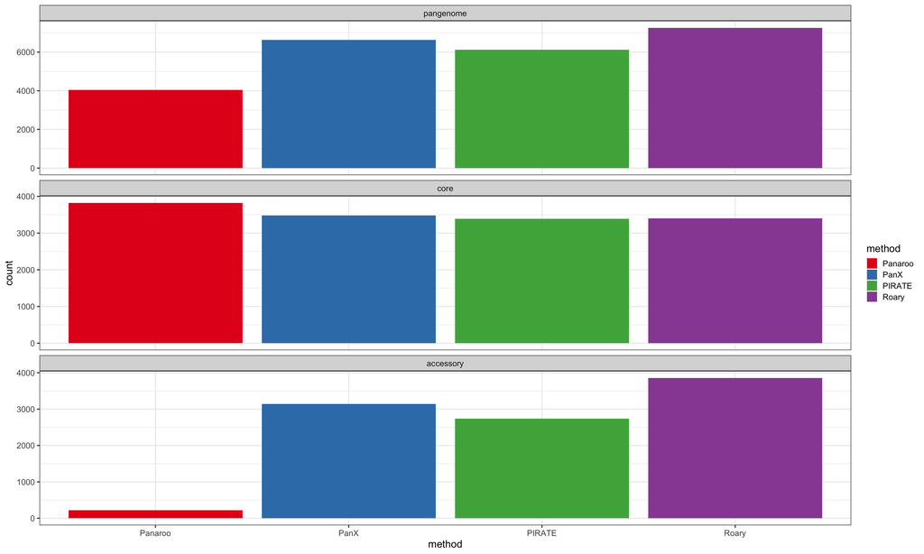

```r
result_99_df <- imap_dfr(pa_matrices, ~data.frame(method = .y, data.frame(t(calc_pan_sizes(.x,
    core_fraction = 0.99))), stringsAsFactors = FALSE))
result_99_df <- data.table::melt(result_99_df, id.vars = "method", variable.name = "category",
    value.name = "count")

ggplot(result_99_df, aes(x = method, y = count, fill = method)) + geom_col() +
    facet_wrap(~category, ncol = 1, scales = "free_y") + theme_bw(base_size = 16) +
    scale_fill_brewer(palette = "Set1")
```

Now a plot with ‘core’ defined as present in at least 98% of samples.

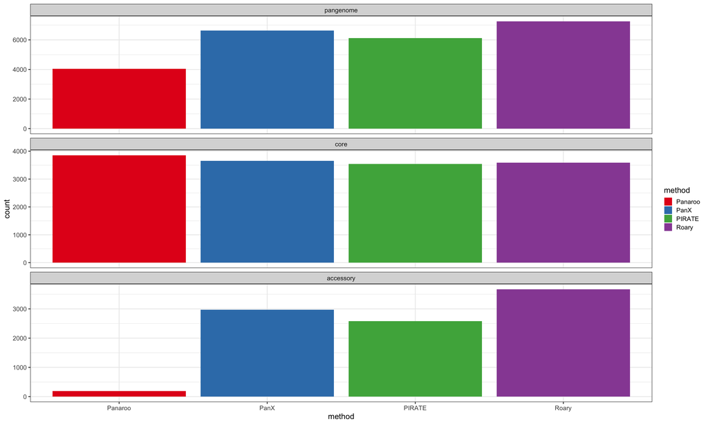

```r
result_98_df <- imap_dfr(pa_matrices, ~data.frame(method = .y, data.frame(t(calc_pan_sizes(.x,
    core_fraction = 0.98))), stringsAsFactors = FALSE))
result_98_df <- data.table::melt(result_98_df, id.vars = "method", variable.name = "category",
    value.name = "count")

ggplot(result_98_df, aes(x = method, y = count, fill = method)) + geom_col() +
    facet_wrap(~category, ncol = 1, scales = "free_y") + theme_bw(base_size = 16) +
    scale_fill_brewer(palette = "Set1")
```

Now a plot with ‘core’ defined as present in at least 95% of samples

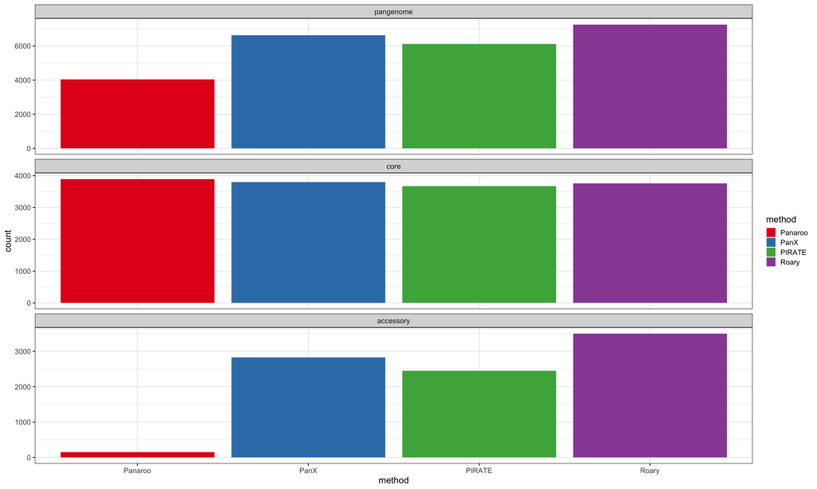

```r
result_95_df <- imap_dfr(pa_matrices, ~data.frame(method = .y, data.frame(t(calc_pan_sizes(.x,
    core_fraction = 0.95))), stringsAsFactors = FALSE))
result_95_df <- data.table::melt(result_95_df, id.vars = "method", variable.name = "category",
    value.name = "count")

ggplot(result_95_df, aes(x = method, y = count, fill = method)) + geom_col() +
    facet_wrap(~category, ncol = 1, scales = "free_y") + theme_bw(base_size = 16) +
    scale_fill_brewer(palette = "Set1")
```